# allThatGlittersIsNotGold

Rohit Tolawat

6/21/2020

```r
pacman::p_load(caret, data.table, ggplot2,gridExtra,ggpubr,MASS,stats,mlmetrics)
knitr::opts_chunk$set(echo = FALSE, fig.width=12, fig.height=6, fig.path = 'Figs/')
options(digits = 3)
```

```
## Classes 'data.table' and 'data.frame':   255 obs. of  4 variables:
##  $ Location         : Factor w/ 3 levels "A","B","C": 2 1 2 3 2 3 3 3 3 2 ...
##  $ Number.of.Records: int  1 1 1 1 1 1 1 1 1 1 ...
##  $ Power.output..MW.: num  23.6 0.16 1.32 18.89 12.89 ...
##  $ Wind.Speed..m.s. : num  14.29 2.01 3.55 10.55 8.58 ...
##  - attr(*, ".internal.selfref")=<externalptr>
```

#Insights corner: The dataset contains the speed of wind and power output across various locations. Wind speed is in meters per second and power output is in megawatts.

```
##  Location Number.of.Records Power.output..MW. Wind.Speed..m.s.
##  A: 37    Min.   :1         Min.   : 0.00     Min.   : 1.10
##  B:109    1st Qu.:1         1st Qu.: 1.53     1st Qu.: 4.00
##  C:109    Median :1         Median : 8.60     Median : 6.83
##           Mean   :1         Mean   : 9.68     Mean   : 7.21
##           3rd Qu.:1         3rd Qu.:15.57     3rd Qu.: 9.60
##           Max.   :1         Max.   :29.02     Max.   :18.32
```

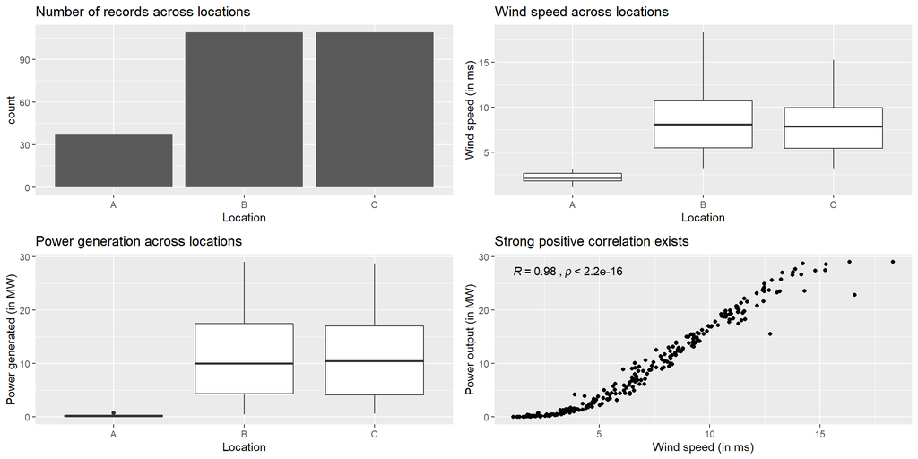

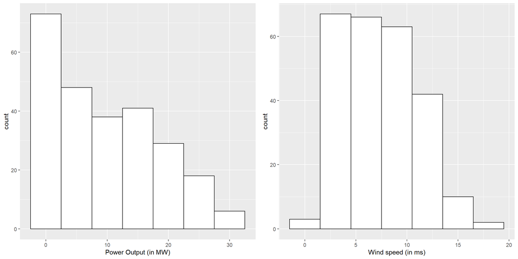

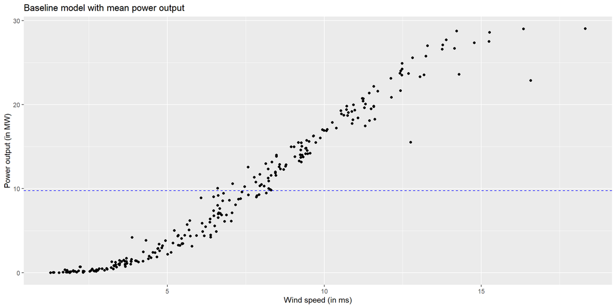

```
##
## Call:
## lm(formula = Power.output..MW. ~ Wind.Speed..m.s., data = windPowerGenerationData.train)
##
## Residuals:
##    Min     1Q Median     3Q    Max
## -7.872 -1.130 -0.076  1.220  3.718
##
## Coefficients:
##                  Estimate Std. Error t value Pr(>|t|)
## (Intercept)       -6.5823     0.2484   -26.5   <2e-16 ***
## Wind.Speed..m.s.   2.2507     0.0307    73.4   <2e-16 ***
## ---
## Signif. codes:  0 '***' 0.001 '**' 0.01 '*' 0.05 '.' 0.1 ' ' 1
##
## Residual standard error: 1.75 on 251 degrees of freedom
## Multiple R-squared:  0.955,  Adjusted R-squared:  0.955
## F-statistic: 5.39e+03 on 1 and 251 DF,  p-value: <2e-16
```

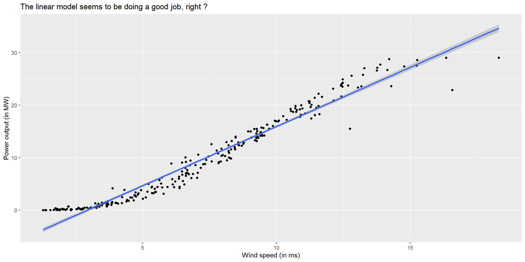

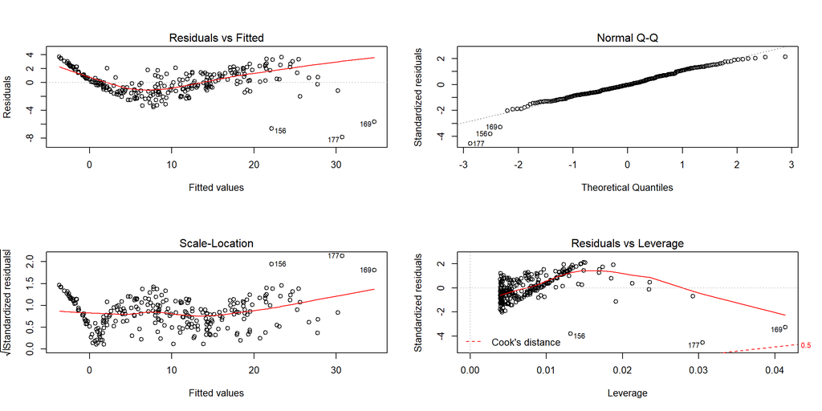

#Insights corner: A high R-squared and low p-values of the coefficient does not necessarily mean that the linear model is good enough. What must also be investigated is the residual plots of the fitted values. As seen from the plot 1 (top left), the residuals are not homogenously distributed, they seem to be forming a pattern. This indicates the existance of heteroscadesticity, and a basic requirement for linear regression is violated.

#Insights corner: An interesting point in the model built earlier is that the intercept is negative. This is a not valid scenario and is chosen to minimize the least squared residuals. Let us now try to build a model with intercept forced to zero. It implies that there would not be an any power generated if the wind isn’t blowing.

```
##
## Call:
## lm(formula = Power.output..MW. ~ 0 + Wind.Speed..m.s., data = windPowerGenerationData.train)
##
## Residuals:
##    Min     1Q Median     3Q    Max
##  -5.68  -3.98  -2.36   1.08   7.10
##
## Coefficients:
##                  Estimate Std. Error t value Pr(>|t|)
## Wind.Speed..m.s.   1.5224     0.0265    57.5   <2e-16 ***
## ---
## Signif. codes:  0 '***' 0.001 '**' 0.01 '*' 0.05 '.' 0.1 ' ' 1
##
## Residual standard error: 3.41 on 252 degrees of freedom
## Multiple R-squared:  0.929,  Adjusted R-squared:  0.929
## F-statistic: 3.31e+03 on 1 and 252 DF,  p-value: <2e-16
```

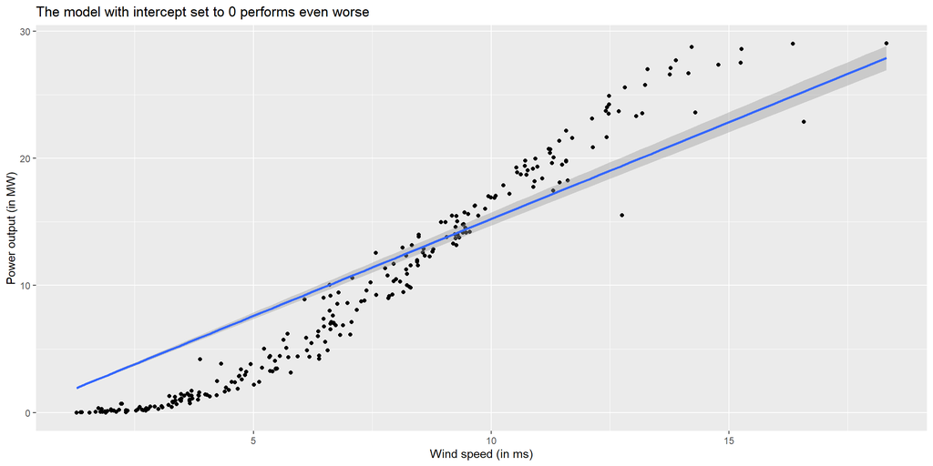

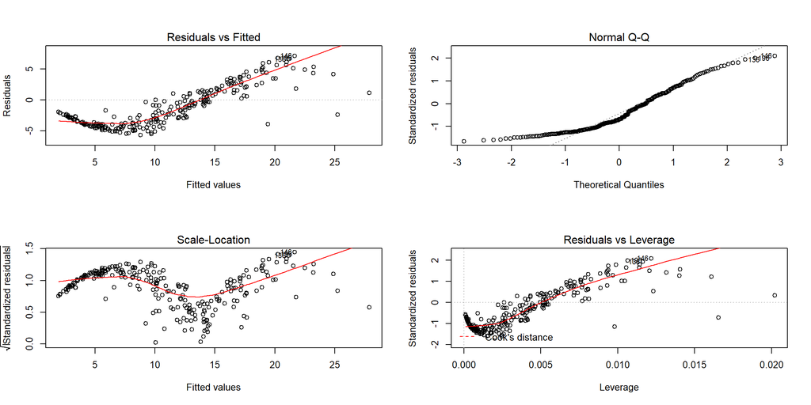

#Insights corner: The effects of heteroscadesticity are more relevant when the intercept is forced to zero. This is evident from the residual v/s fitted plot where the model overpredicts initially and underpredicts with the increase in wind speed in ms. Clearly the relationship between the predictor and the response variable is not linear. Let us try building a non-linear model.

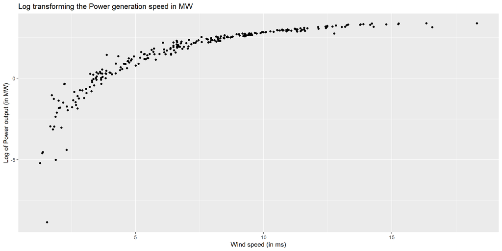

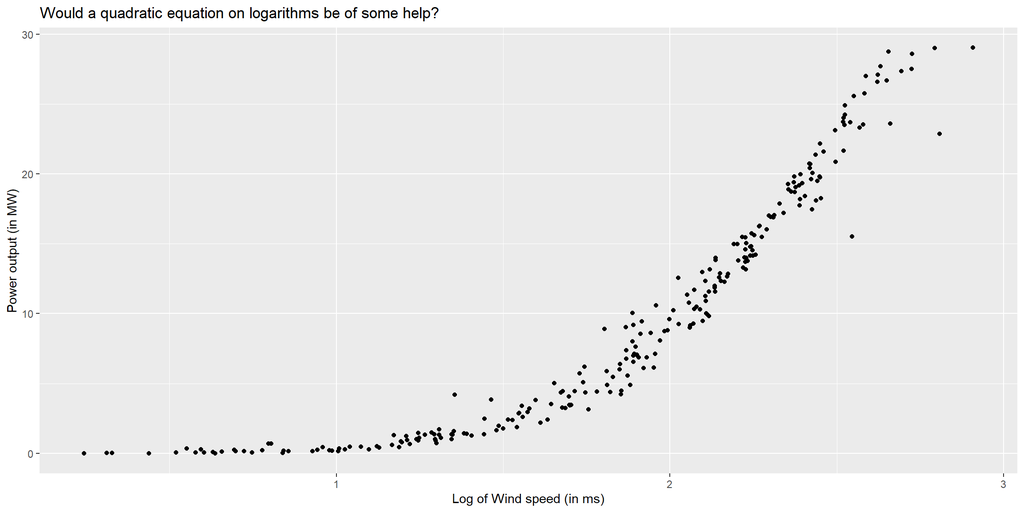

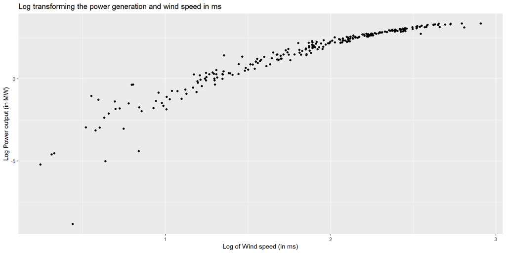

```
##
## Call:
## lm(formula = Power.output..MW. ~ log(Wind.Speed..m.s.) + windSpeedSquared,
##     data = windPowerGenerationData.train)
##
## Residuals:
##    Min     1Q Median     3Q    Max
## -3.751 -0.752  0.072  0.843  3.246
##
## Coefficients:
##                       Estimate Std. Error t value Pr(>|t|)
## (Intercept)              7.396      0.541    13.7   <2e-16 ***
## log(Wind.Speed..m.s.)  -17.206      0.693   -24.8   <2e-16 ***
## windSpeedSquared         9.182      0.208    44.1   <2e-16 ***
## ---
## Signif. codes:  0 '***' 0.001 '**' 0.01 '*' 0.05 '.' 0.1 ' ' 1
##
## Residual standard error: 1.2 on 247 degrees of freedom
## Multiple R-squared:  0.979,  Adjusted R-squared:  0.979
## F-statistic: 5.73e+03 on 2 and 247 DF,  p-value: <2e-16
```

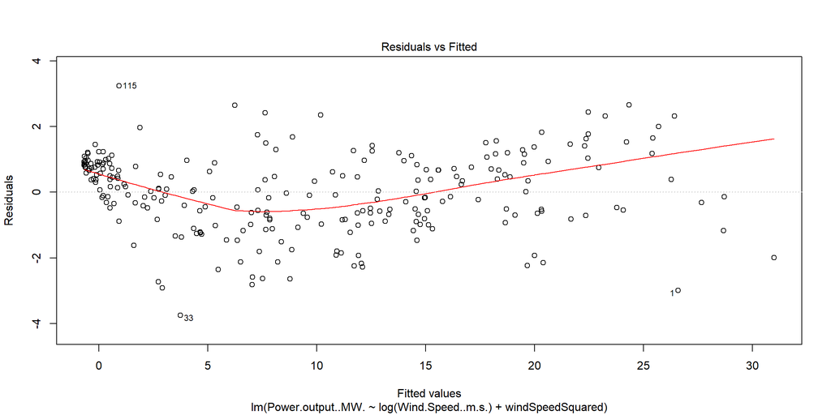

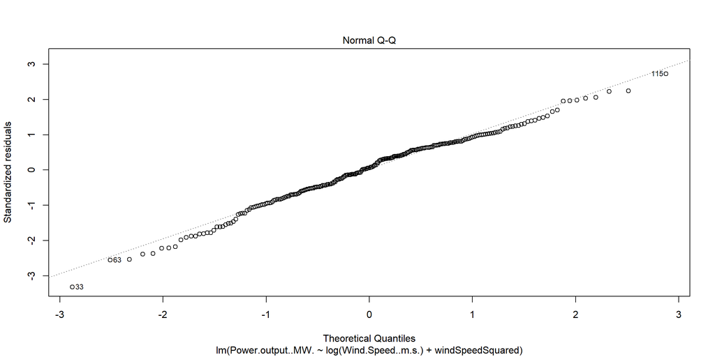

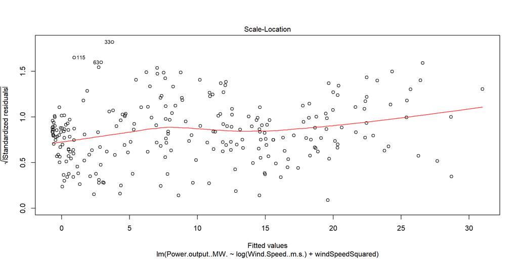

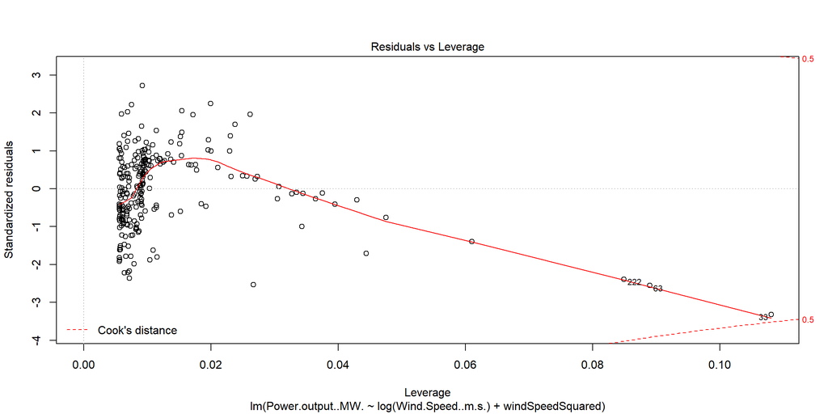

```
## Classes 'data.table' and 'data.frame':   250 obs. of  6 variables:
##  $ Location          : Factor w/ 3 levels "A","B","C": 2 1 2 3 2 3 3 3 3 2 ...
##  $ Number.of.Records : int  1 1 1 1 1 1 1 1 1 1 ...
##  $ Power.output..MW. : num  23.6 0.16 1.32 18.89 12.89 ...
##  $ Wind.Speed..m.s.  : num  14.29 2.01 3.55 10.55 8.58 ...
##  $ windSpeedSquared  : num  7.075 0.487 1.602 5.549 4.622 ...
##  $ predictedQuadratic: num  26.594 -0.14 0.328 17.821 12.845 ...
##  - attr(*, ".internal.selfref")=<externalptr>
```

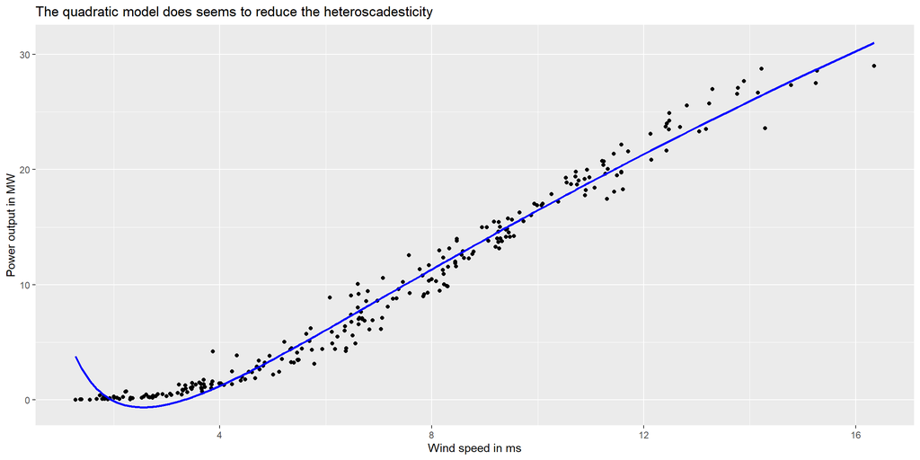

#Insights corner: Are we overfitting? Let us cross-validate our dataset.

[figure not shown]

```
##               modelType Train RMSE values Test RMSE values
## 1:       Baseline model              8.18             8.06
## 2:    Linear regression              1.59             1.60
## 3: Nonlinear regression              1.19             1.28
```

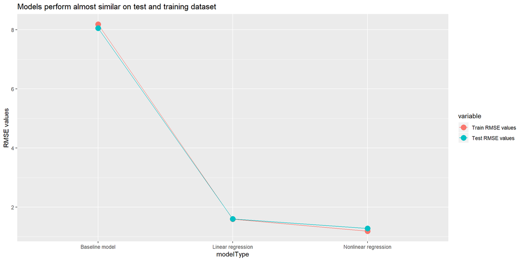

#Insights corner: We started with the baseline model assuming we had no information on the wind speed and therefore using the mean of power output as the base. This wasn’t a good model. We then tried fitting a line through the cloud of data, the model performed well on the training data but the predictions weren’t consistent. Heteroscadesticity in the residual v/s fitted plot compelled us to move towards a polynomial plot. The quadratic logarithmic plot, to some extent reduced heteroscadesticty (can’t say eliminated). This model was cross-validated where it performed consistently and run on the training data. Goodness of the model was measured with its RMSE values and polynomial regression seems to be perform marginally better as compared to the linear model. The results are as tabulated above.